# Airbnb and Charlottetown

Urban Politics and Governance Research Group

June 2019

# Airbnb and Charlottetown

### Urban Politics and Governance Research Group

### April 2019

**Airbnb Today**

Airbnb listings are a common presence in Charlottetown, with 678 active listings on April 30 2019, averaging 679 over the past twelve months. The corresponding listings have generated approximately $6,859,000 in revenue over the same time period.

*Figure 1* shows the distribution of Airbnb listings throughout Charlottetown, by listing type and revenue. As Airbnb hides the exact location of the listings, the locations may be obfuscated by up to 200 meters.

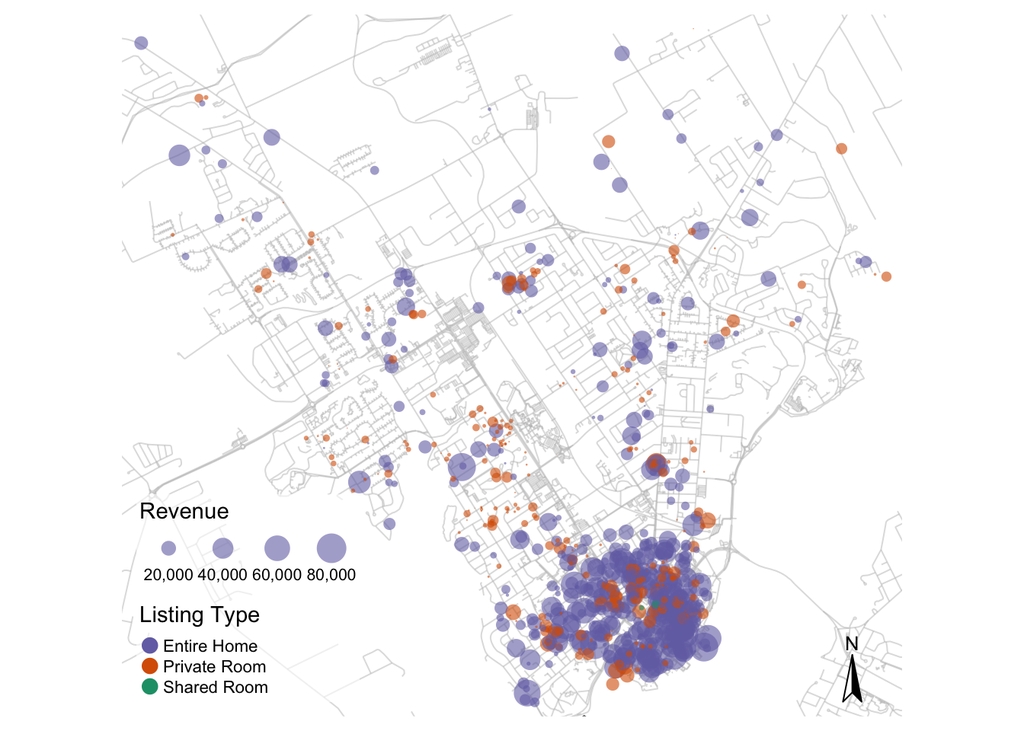

**The Evolution of Airbnb**

Airbnb has had an increasing presence in Charlottetown, with *Figure 2* showing its evolution from July 01 2016 to April 30 2019. It is evident that the number of listings has dramatically increased over the past years.

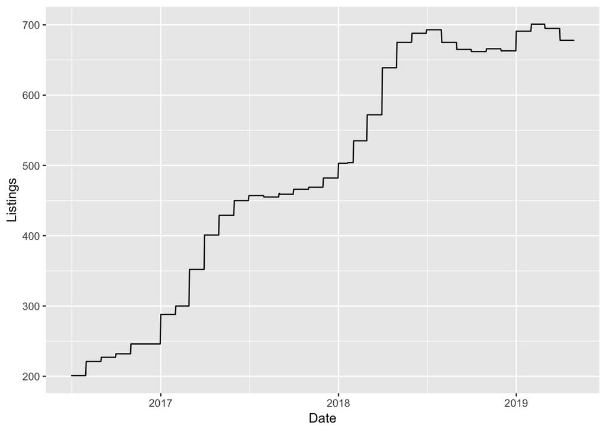

**Housing Loss**

Listings consist of three types: entire homes or apartments, private rooms, or shared rooms. Entire homes or apartments represent housing that has likely been removed from the long-term rental market. 73.3% of listings are entire homes or apartments. This percentage has increased over the past twelve months from 66.8%. Though private rooms and shared rooms are often indicative of hosts sharing their primary residence, this is not always the case. Ghost hotels, three or more private room listings in the same housing unit, also contribute to housing loss, as the separate private room listings make up an entire housing unit removed from the long-term rental housing market.

When considering both ghost hotels and entire home and apartment listings, it is estimated that Airbnb has removed 242 housing units from the long-term rental market over the past year, increasing from 236 units the year prior.

As more units are converted into short-term rentals, Airbnb increasingly contributes to the removal of housing units from the long-term rental market.